# 成為初級資料分析師 | Python 機器學習

> Matplotlib 101

## 郭耀仁

## 大綱

- Matplotlib 解決了什麼問題
- Matplotlib 基礎
- Matplotlib 技巧

## Matplotlib 解決了什麼問題

## Matplotlib，或者更廣泛地說資料視覺化能夠將抽象資料轉換為具體的輸出

- 分配（Distribution）
- 函數（Function）
- 方程式（Formula）

```python
import numpy as np

arr = np.random.random(10000)
print(arr)
```

```
[0.57907602 0.88917318 0.72465085 ... 0.79829058 0.05983296 0.28873631]
```

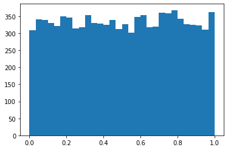

```python
%matplotlib inline
import matplotlib.pyplot as plt

fig, ax = plt.subplots()
ax.hist(arr, bins=30)
plt.show()
```

```python
arr = np.random.normal(size=10000)
print(arr)
```

```
[ 0.74028476 -0.40180099 -0.61601392 ... -0.15664529 -1.02970436
  0.91877319]
```

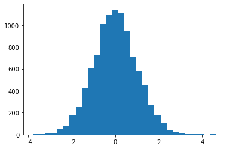

```python
fig, ax = plt.subplots()
ax.hist(arr, bins=30)
plt.show()
```

## $f(x) = sin(x)$

```python
from numpy import pi

x = np.linspace(0, 4*pi)
f = np.sin(x)
print(x)
print(f)
```

```
[ 0.          0.25645654  0.51291309  0.76936963  1.02582617  1.28228272
  1.53873926  1.7951958   2.05165235  2.30810889  2.56456543  2.82102197
  3.07747852  3.33393506  3.5903916   3.84684815  4.10330469  4.35976123
  4.61621778  4.87267432  5.12913086  5.38558741  5.64204395  5.89850049
  6.15495704  6.41141358  6.66787012  6.92432667  7.18078321  7.43723975
  7.69369629  7.95015284  8.20660938  8.46306592  8.71952247  8.97597901
  9.23243555  9.4888921   9.74534864 10.00180518 10.25826173 10.51471827
 10.77117481 11.02763136 11.2840879  11.54054444 11.79700098 12.05345753
 12.30991407 12.56637061]
[ 0.00000000e+00  2.53654584e-01  4.90717552e-01  6.95682551e-01
  8.55142763e-01  9.58667853e-01  9.99486216e-01  9.74927912e-01
  8.86599306e-01  7.40277997e-01  5.45534901e-01  3.15108218e-01
  6.40702200e-02 -1.91158629e-01 -4.33883739e-01 -6.48228395e-01
 -8.20172255e-01 -9.38468422e-01 -9.95379113e-01 -9.87181783e-01
 -9.14412623e-01 -7.81831482e-01 -5.98110530e-01 -3.75267005e-01
 -1.27877162e-01  1.27877162e-01  3.75267005e-01  5.98110530e-01
  7.81831482e-01  9.14412623e-01  9.87181783e-01  9.95379113e-01
  9.38468422e-01  8.20172255e-01  6.48228395e-01  4.33883739e-01
  1.91158629e-01 -6.40702200e-02 -3.15108218e-01 -5.45534901e-01
 -7.40277997e-01 -8.86599306e-01 -9.74927912e-01 -9.99486216e-01
 -9.58667853e-01 -8.55142763e-01 -6.95682551e-01 -4.90717552e-01
 -2.53654584e-01 -4.89858720e-16]
```

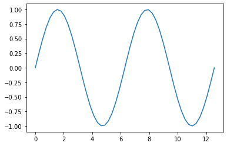

```python
fig, ax = plt.subplots()
ax.plot(x, f)
plt.show()
```

$S(x) = \frac{1}{1 + e^{-x}}$

```python
def sigmoid(x):
    return 1 / (1 + np.exp(-x))

x = np.linspace(-10, 10)
f = sigmoid(x)
print(x)
print(f)
```

```
[-10.          -9.59183673  -9.18367347  -8.7755102   -8.36734694
  -7.95918367  -7.55102041  -7.14285714  -6.73469388  -6.32653061
  -5.91836735  -5.51020408  -5.10204082  -4.69387755  -4.28571429
  -3.87755102  -3.46938776  -3.06122449  -2.65306122  -2.24489796
  -1.83673469  -1.42857143  -1.02040816  -0.6122449   -0.20408163
   0.20408163   0.6122449    1.02040816   1.42857143   1.83673469
   2.24489796   2.65306122   3.06122449   3.46938776   3.87755102
   4.28571429   4.69387755   5.10204082   5.51020408   5.91836735
   6.32653061   6.73469388   7.14285714   7.55102041   7.95918367
   8.36734694   8.7755102    9.18367347   9.59183673  10.        ]
[4.53978687e-05 6.82792246e-05 1.02692018e-04 1.54446212e-04
 2.32277160e-04 3.49316192e-04 5.25297471e-04 7.89865942e-04
 1.18752721e-03 1.78503502e-03 2.68237328e-03 4.02898336e-03
 6.04752187e-03 9.06814944e-03 1.35769169e-02 2.02816018e-02
 3.01959054e-02 4.47353464e-02 6.58005831e-02 9.57904660e-02
 1.37437932e-01 1.93321370e-01 2.64947903e-01 3.51547277e-01
 4.49155938e-01 5.50844062e-01 6.48452723e-01 7.35052097e-01
 8.06678630e-01 8.62562068e-01 9.04209534e-01 9.34199417e-01
 9.55264654e-01 9.69804095e-01 9.79718398e-01 9.86423083e-01
 9.90931851e-01 9.93952478e-01 9.95971017e-01 9.97317627e-01
 9.98214965e-01 9.98812473e-01 9.99210134e-01 9.99474703e-01
 9.99650684e-01 9.99767723e-01 9.99845554e-01 9.99897308e-01
 9.99931721e-01 9.99954602e-01]
```

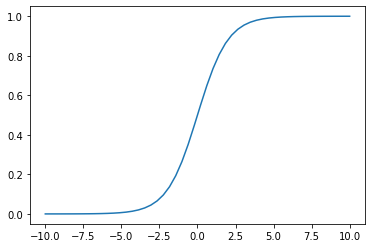

```python
fig, ax = plt.subplots()
ax.plot(x, f)
plt.show()
```

## matplotlib 基礎

## 什麼是 matplotlib？

> Matplotlib is a Python 2D plotting library which produces publication quality figures.

## 什麼是 pyplot？

> matplotlib.pyplot is a collection of command style functions that make matplotlib work like MATLAB.

## 安裝與載入 matplotlib、pyplot

- 安裝

```
# run in bash shell
pip install matplotlib
```

- 載入

```
# run in python console
import matplotlib as mpl
import matplotlib.pyplot as plt
```

## 作圖流程

- 將資料整理為 `ndarray` 格式
- 呼叫 `plt.subplots()` 同時展開「畫布物件」與「軸物件」
- 依照探索需求呼叫「軸物件」的作圖方法
- 依照設計需求添加「軸物件」的元素
- 呼叫 `plt.show()` 顯示圖形

## 作圖流程：一個簡單的函數圖形（線圖）

## 將資料整理為 `ndarray` 格式

```python
x = np.linspace(-2*np.pi, 2*np.pi)
f = np.sin(x)
print(type(x))
print(type(f))
```

```
<class 'numpy.ndarray'>
<class 'numpy.ndarray'>
```

## 呼叫 `plt.subplots()` 同時展開「畫布物件」與「軸物件」

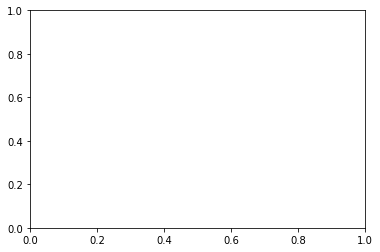

```python
fig, ax = plt.subplots()
```

## 依照探索需求呼叫「軸物件」的作圖方法

```python
ax.plot(x, f)
```

## 依照設計需求添加「軸物件」的元素

```python
ax.set_title("A simple line plot for $sin(x)$")
ax.set_xlabel("$x$")
ax.set_ylabel("$sin(x)$")
```

## 呼叫 `plt.show()` 顯示圖形

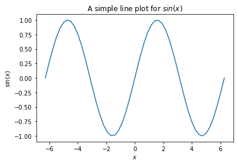

```python
fig, ax = plt.subplots()
ax.plot(x, f)
ax.set_title("A simple line plot for $sin(x)$")
ax.set_xlabel("$x$")
ax.set_ylabel("$sin(x)$")
plt.show()
```

## 在機器學習中會用到的視覺化圖形

- 觀察資料相關性的散佈圖（Scatter Plot）
- 觀察類別型資料的長條圖（Bar Plot）
- 觀察資料分佈的直方圖（Histogram）
- 觀察數值變化趨勢的線圖（Line Plot）
- 觀察地形起伏的等高線圖（Contour Plot）或表面圖（Surface Plot）
- 觀察圖片的顯示圖（Image Show）

## 觀察資料相關性的散佈圖（Scatter Plot）：`ax.scatter()`

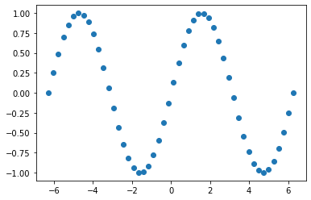

```python
x = np.linspace(-2*np.pi, 2*np.pi)
f = np.sin(x)
fig, ax = plt.subplots()
ax.scatter(x, f)
plt.show()
```

## 觀察類別型資料的長條圖（Bar Plot）：`ax.bar()`/`ax.barh()`

```python
def is_prime(x):
    div_cnt = 0
    for i in range(1, x+1):
        if x % i == 0:
            div_cnt += 1
        if div_cnt > 2:
            break
    return div_cnt == 2
is_prime_ufunc = np.vectorize(is_prime)
arr = np.arange(1, 101)
n_primes = is_prime_ufunc(arr).sum()
n_non_primes = np.logical_not(is_prime_ufunc(arr)).sum()
```

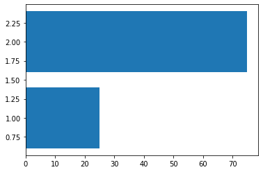

```python
y = np.array([n_primes, n_non_primes])
x = np.array([1, 2])
fig, ax = plt.subplots()
ax.barh(x, y)
plt.show()
```

## 觀察資料分佈的直方圖（Histogram）：`ax.hist()`

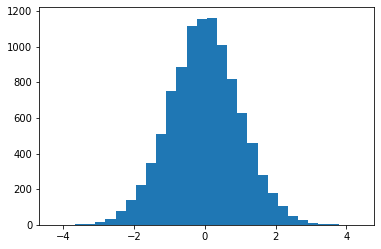

```python
arr = np.random.normal(size=10000)
fig, ax = plt.subplots()
ax.hist(arr, bins=30)
plt.show()
```

## 觀察數值變化趨勢的線圖（Line Plot）：`ax.plot()`

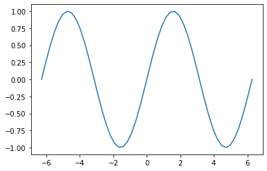

```python
x = np.linspace(-2*np.pi, 2*np.pi)
f = np.sin(x)
fig, ax = plt.subplots()
ax.plot(x, f)
plt.show()
```

## 觀察地形起伏的等高線圖（Contour Plot）或表面圖（Surface Plot）

```python
x = np.linspace(-3.0, 3.0)
y = np.linspace(-2.0, 2.0)
X, Y = np.meshgrid(x, y)
Z1 = np.exp(-X**2 - Y**2)
Z2 = np.exp(-(X - 1)**2 - (Y - 1)**2)
Z = (Z1 - Z2) * 2
```

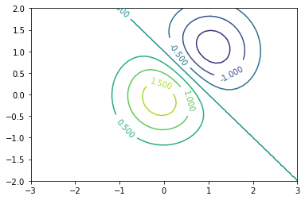

```python
fig, ax = plt.subplots()
CS = ax.contour(X, Y, Z)
ax.clabel(CS, inline=1, fontsize=10)
plt.show()
```

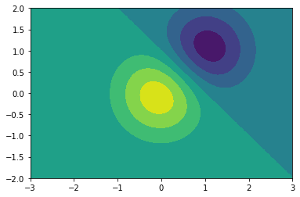

```python
fig, ax = plt.subplots()
CS = ax.contourf(X, Y, Z)
plt.show()
```

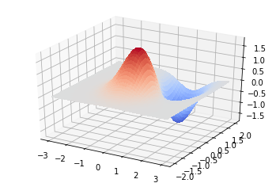

```python
from mpl_toolkits.mplot3d import Axes3D
from matplotlib import cm

fig = plt.figure()
ax = fig.gca(projection='3d')
surf = ax.plot_surface(X, Y, Z, linewidth=0, antialiased=False, cmap=cm.coolwarm)
plt.show()
```

## 觀察圖片的顯示圖（Image Show）：數值陣列

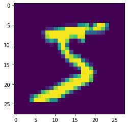

```python
import tensorflow as tf

(x_train, y_train), (x_test, y_test) = tf.keras.datasets.mnist.load_data(path="mnist.npz")
fig, ax = plt.subplots()
ax.imshow(x_train[0])
plt.show()
```

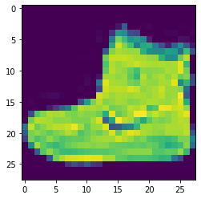

```python
import tensorflow as tf

(x_train, y_train), (x_test, y_test) = tf.keras.datasets.fashion_mnist.load_data()
fig, ax = plt.subplots()
ax.imshow(x_train[0])
plt.show()
```

## 觀察圖片的顯示圖（Image Show）：圖片檔案

[figure not shown]

```python
from tensorflow.keras.preprocessing.image import load_img

#!wget --output-document=batman_meme.jpg https://i.imgur.com/vYrSnI8.jpg
batman_meme = load_img("batman_meme.jpg")
fig, ax = plt.subplots()
ax.imshow(batman_meme)
plt.show()
```

## Matplotlib 技巧

## 常用的 Matplotlib 技巧

- 加入圖標題與軸標籤
- 中文支援
- 調整座標軸
- 加入註釋
- 加入與調整圖例
- 在一個畫布上繪製多個子圖形
- 調整主題樣式表

## 加入圖標題與軸標籤

呼叫「軸物件」的對應方法

- `ax.set_title()`
- `ax.set_xlabel()`
- `ax.set_ylabel()`

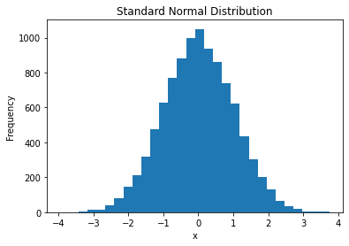

```python
arr = np.random.normal(size=10000)
fig, ax = plt.subplots()
ax.hist(arr, bins=30)
ax.set_title("Standard Normal Distribution")
ax.set_xlabel("x")
ax.set_ylabel("Frequency")
plt.show()
```

## 加入有中文的圖標題與軸標籤會出現無法顯示的問題

[output not shown]

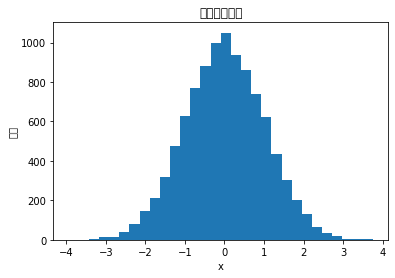

```python
fig, ax = plt.subplots()
ax.hist(arr, bins=30)
ax.set_title("標準常態分配")
ax.set_xlabel("x")
ax.set_ylabel("頻率")
plt.show()
```

## 中文支援

指定支援中文的字體來解決：`mpl.font_manager.FontProperties`

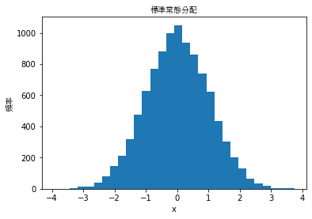

```python
fig, ax = plt.subplots()
# 指定支援中文的字體來解決
myfont = mpl.font_manager.FontProperties(fname="/System/Library/Fonts/STHeiti Light.ttc")
ax.hist(arr, bins=30)
ax.set_title("標準常態分配", fontproperties=myfont)
ax.set_xlabel("x")
ax.set_ylabel("頻率", fontproperties=myfont)
plt.show()
```

## 調整座標軸

呼叫「軸物件」的對應方法

- `ax.set_xlim()`
- `ax.set_ylim()`
- `ax.set_xticks()`
- `ax.set_yticks()`
- `ax.set_xticklabels()`
- `ax.set_yticklabels()`

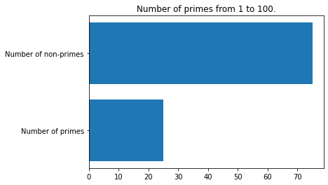

```python
arr = np.arange(1, 101)
n_primes = is_prime_ufunc(arr).sum()
n_non_primes = np.logical_not(is_prime_ufunc(arr)).sum()
y = np.array([n_primes, n_non_primes])
x = np.array([1, 2])
fig, ax = plt.subplots()
ax.barh(x, y)
ax.set_title("Number of primes from 1 to 100.")
ax.set_yticks([1, 2])
ax.set_yticklabels(['Number of primes', 'Number of non-primes'])
plt.show()
```

## 加入註釋

`ax.text()`

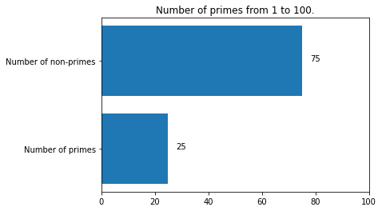

```python
fig, ax = plt.subplots()
ax.barh(x, y)
ax.set_title("Number of primes from 1 to 100.")
ax.set_yticks([1, 2])
ax.set_yticklabels(['Number of primes', 'Number of non-primes'])
for i in range(2):
    ax.text(y[i] + 3, i + 1 , '{}'.format(y[i]))
ax.set_xlim(0, 100)
plt.show()
```

## 加入與調整圖例

- 使用 `label` 參數
- `ax.legend()`

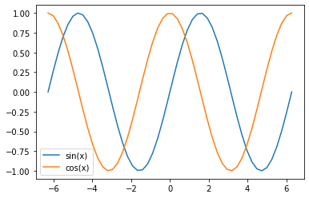

```python
x = np.linspace(-2*np.pi, 2*np.pi)
f0 = np.sin(x)
f1 = np.cos(x)
fig, ax = plt.subplots()
ax.plot(x, f0, label="sin(x)")
ax.plot(x, f1, label="cos(x)")
ax.legend()
plt.show()
```

## 在一個畫布上繪製多個子圖形

`plt.subplots()`

```python
x = np.linspace(-2*np.pi, 2*np.pi, 100)
f0 = np.sin(x)
f1 = np.cos(x)
f2 = np.tan(x)
print(f2)
print(np.diff(f2))
```

```
[ 2.44929360e-16  1.27619174e-01  2.59464150e-01  4.00339609e-01
  5.56385058e-01  7.36284401e-01  9.53498074e-01  1.23089871e+00
  1.61169269e+00  2.18969456e+00  3.21602127e+00  5.67128182e+00
  2.09925835e+01 -1.25786160e+01 -4.77915322e+00 -2.88931025e+00
 -2.01770128e+00 -1.50305055e+00 -1.15406152e+00 -8.94674368e-01
 -6.88449662e-01 -5.15535831e-01 -3.63970234e-01 -2.25859960e-01
 -9.54884223e-02  3.17439152e-02  1.60011316e-01  2.93626493e-01
  4.37645272e-01  5.98703173e-01  7.86408692e-01  1.01599385e+00
  1.31398466e+00  1.73205081e+00  2.38738432e+00  3.61702392e+00
  6.95515277e+00  6.30200685e+01 -8.96656988e+00 -4.12205614e+00
 -2.61749489e+00 -1.86641404e+00 -1.40430351e+00 -1.08265515e+00
 -8.39099631e-01 -6.42660977e-01 -4.76002082e-01 -3.28431672e-01
 -1.92734202e-01 -6.35518701e-02  6.35518701e-02  1.92734202e-01
  3.28431672e-01  4.76002082e-01  6.42660977e-01  8.39099631e-01
  1.08265515e+00  1.40430351e+00  1.86641404e+00  2.61749489e+00
  4.12205614e+00  8.96656988e+00 -6.30200685e+01 -6.95515277e+00
 -3.61702392e+00 -2.38738432e+00 -1.73205081e+00 -1.31398466e+00
 -1.01599385e+00 -7.86408692e-01 -5.98703173e-01 -4.37645272e-01
 -2.93626493e-01 -1.60011316e-01 -3.17439152e-02  9.54884223e-02
  2.25859960e-01  3.63970234e-01  5.15535831e-01  6.88449662e-01
  8.94674368e-01  1.15406152e+00  1.50305055e+00  2.01770128e+00
  2.88931025e+00  4.77915322e+00  1.25786160e+01 -2.09925835e+01
 -5.67128182e+00 -3.21602127e+00 -2.18969456e+00 -1.61169269e+00
 -1.23089871e+00 -9.53498074e-01 -7.36284401e-01 -5.56385058e-01
 -4.00339609e-01 -2.59464150e-01 -1.27619174e-01 -2.44929360e-16]
[  0.12761917   0.13184498   0.14087546   0.15604545   0.17989934
   0.21721367   0.27740064   0.38079398   0.57800188   1.0263267
   2.45526055  15.32130164 -33.57119947   7.79946279   1.88984297
   0.87160897   0.51465074   0.34898903   0.25938715   0.20622471
   0.17291383   0.1515656    0.13811027   0.13037154   0.12723234
   0.1282674    0.13361518   0.14401878   0.1610579    0.18770552
   0.22958516   0.29799081   0.41806614   0.65533351   1.2296396
   3.33812885  56.06491573 -71.98663838   4.84451373   1.50456126
   0.75108085   0.46211053   0.32164836   0.24355552   0.19643865
   0.1666589    0.14757041   0.13569747   0.12918233   0.12710374
   0.12918233   0.13569747   0.14757041   0.1666589    0.19643865
   0.24355552   0.32164836   0.46211053   0.75108085   1.50456126
   4.84451373 -71.98663838  56.06491573   3.33812885   1.2296396
   0.65533351   0.41806614   0.29799081   0.22958516   0.18770552
   0.1610579    0.14401878   0.13361518   0.1282674    0.12723234
   0.13037154   0.13811027   0.1515656    0.17291383   0.20622471
   0.25938715   0.34898903   0.51465074   0.87160897   1.88984297
   7.79946279 -33.57119947  15.32130164   2.45526055   1.0263267
   0.57800188   0.38079398   0.27740064   0.21721367   0.17989934
   0.15604545   0.14087546   0.13184498   0.12761917]
```

```python
f2[:-1][np.diff(f2) < 0] = np.nan
print(f2)
```

```
[ 2.44929360e-16  1.27619174e-01  2.59464150e-01  4.00339609e-01
  5.56385058e-01  7.36284401e-01  9.53498074e-01  1.23089871e+00
  1.61169269e+00  2.18969456e+00  3.21602127e+00  5.67128182e+00
             nan -1.25786160e+01 -4.77915322e+00 -2.88931025e+00
 -2.01770128e+00 -1.50305055e+00 -1.15406152e+00 -8.94674368e-01
 -6.88449662e-01 -5.15535831e-01 -3.63970234e-01 -2.25859960e-01
 -9.54884223e-02  3.17439152e-02  1.60011316e-01  2.93626493e-01
  4.37645272e-01  5.98703173e-01  7.86408692e-01  1.01599385e+00
  1.31398466e+00  1.73205081e+00  2.38738432e+00  3.61702392e+00
  6.95515277e+00             nan -8.96656988e+00 -4.12205614e+00
 -2.61749489e+00 -1.86641404e+00 -1.40430351e+00 -1.08265515e+00
 -8.39099631e-01 -6.42660977e-01 -4.76002082e-01 -3.28431672e-01
 -1.92734202e-01 -6.35518701e-02  6.35518701e-02  1.92734202e-01
  3.28431672e-01  4.76002082e-01  6.42660977e-01  8.39099631e-01
  1.08265515e+00  1.40430351e+00  1.86641404e+00  2.61749489e+00
  4.12205614e+00             nan -6.30200685e+01 -6.95515277e+00
 -3.61702392e+00 -2.38738432e+00 -1.73205081e+00 -1.31398466e+00
 -1.01599385e+00 -7.86408692e-01 -5.98703173e-01 -4.37645272e-01
 -2.93626493e-01 -1.60011316e-01 -3.17439152e-02  9.54884223e-02
  2.25859960e-01  3.63970234e-01  5.15535831e-01  6.88449662e-01
  8.94674368e-01  1.15406152e+00  1.50305055e+00  2.01770128e+00
  2.88931025e+00  4.77915322e+00             nan -2.09925835e+01
 -5.67128182e+00 -3.21602127e+00 -2.18969456e+00 -1.61169269e+00
 -1.23089871e+00 -9.53498074e-01 -7.36284401e-01 -5.56385058e-01
 -4.00339609e-01 -2.59464150e-01 -1.27619174e-01 -2.44929360e-16]
```

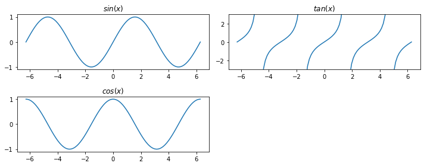

```python
fig, axes = plt.subplots(2, 2, figsize=(10, 4))
# 繪製子圖
axes[0, 0].plot(x, f0)
axes[0, 0].set_title('$sin(x)$')
axes[1, 0].plot(x, f1)
axes[1, 0].set_title('$cos(x)$')
axes[0, 1].plot(x, f2)
axes[0, 1].set_title('$tan(x)$')
axes[0, 1].set_ylim(-3, 3)
axes[1, 1].set_visible(False)
plt.tight_layout()
plt.show()
```

## 隨堂練習：將六個三角函數在 $-2\pi$ 至 $2\pi$ 外觀於一個 3x2 的畫布上顯示

- $sin(x)$
- $cos(x)$
- $tan(x)$
- $cot(x) = \frac{1}{tan(x)}$
- $sec(x) = \frac{1}{cos(x)}$
- $csc(x) = \frac{1}{sin(x)}$

```python
abs_diff = 30
x = np.linspace(-2*np.pi, 2*np.pi, 100)
f0 = np.sin(x)
f1 = np.cos(x)
f2 = np.tan(x)
f3 = np.divide(1, f2)
f4 = np.divide(1, f1)
f5 = np.divide(1, f0)
f2[:-1][np.diff(f2) < 0] = np.nan
f3[:-1][np.diff(f3) > 0] = np.nan
f4[:-1][np.abs(np.diff(f4)) > abs_diff] = np.nan
f5[:-1][np.abs(np.diff(f5)) > abs_diff] = np.nan
arrays = [f0, f1, f2, f3, f4, f5]
plot_titles = ['$sin(x)$', '$cos(x)$', '$tan(x)$', '$cot(x)$', '$sec(x)$', '$csc(x)$']
```

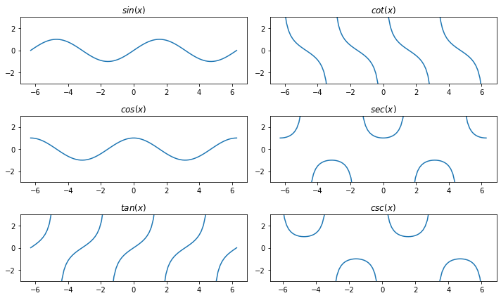

```python
fig, axes = plt.subplots(3, 2, figsize=(10, 6))
plt.setp(axes, ylim=(-3, 3))
for i in range(len(arrays)):
    row_index = i % 3
    col_index = i // 3
    axes[row_index, col_index].plot(x, arrays[i])
    axes[row_index, col_index].set_title(plot_titles[i])
plt.tight_layout()
plt.show()
```

## 調整主題樣式表

呼叫 `plt.style.available` 檢視有哪些可用的主題樣式表

```python
plt.style.available
```

```
['Solarize_Light2',
 '_classic_test_patch',
 'bmh',
 'classic',
 'dark_background',
 'fast',
 'fivethirtyeight',
 'ggplot',
 'grayscale',
 'seaborn',
 'seaborn-bright',
 'seaborn-colorblind',
 'seaborn-dark',
 'seaborn-dark-palette',
 'seaborn-darkgrid',
 'seaborn-deep',
 'seaborn-muted',
 'seaborn-notebook',
 'seaborn-paper',
 'seaborn-pastel',
 'seaborn-poster',
 'seaborn-talk',
 'seaborn-ticks',
 'seaborn-white',
 'seaborn-whitegrid',
 'tableau-colorblind10']
```

## 以 `with` 語法讓樣式表的設定不會全域（整個筆記本）適用

```
with plt.style.context('stylename'):
    make_a_plot()
```

```python
def make_a_subplot(x, f0, f1, f2, f3):
    fig, axes = plt.subplots(2, 2, figsize=(10, 4))
    # 繪製子圖
    plt.setp(axes, ylim=(-3, 3))
    plot_titles = ['$sin(x)$', '$cos(x)$', '$tan(x)$', '$cot(x)$']
    arrays = [f0, f1, f2, f3]
    for i in range(len(arrays)):
        row_index = i % 2
        col_index = i // 2
        axes[row_index, col_index].plot(x, arrays[i])
        axes[row_index, col_index].set_title(plot_titles[i])
    plt.tight_layout()
    plt.show()
```

## 調整主題樣式表：預設

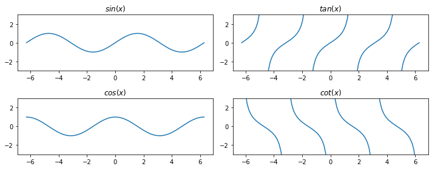

```python
make_a_subplot(x, f0, f1, f2, f3)
```

## 調整主題樣式表：FiveThirtyEight

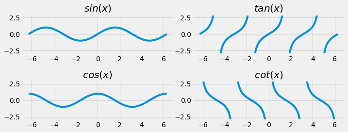

```python
with plt.style.context('fivethirtyeight'):
    make_a_subplot(x, f0, f1, f2, f3)
```

## 調整主題樣式表：ggplot

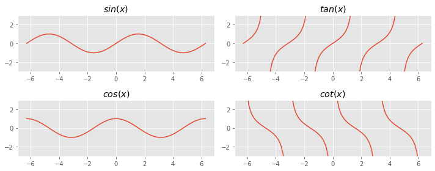

```python
with plt.style.context('ggplot'):
    make_a_subplot(x, f0, f1, f2, f3)
```

## 調整主題樣式表：Seaborn

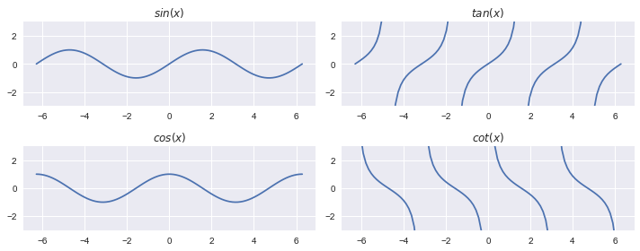

```python
with plt.style.context('seaborn'):
    make_a_subplot(x, f0, f1, f2, f3)
```